# Data Manipulation

Steve Pederson

12 September, 2016

# Data Manipulation

In this session we’ll explore some simple data manipulating, also known as *data munging*

We’ll cover:

- `SQL-` and `Excel-`like functions in `dplyr`
- Changing from wide to long form using `reshape2`
- Editing text using `stringr`

## Loading The Packages

```r
library(readr)
library(dplyr)
library(tibble)
```

If any of those packages failed to load, it may not be installed. This can be simply fixed by typing the following code, where you’ll need to type the name of the missing package where `"package.name"` is written.

```r
install.packages("package.name")
```

- The package `dplyr` works specifically with `data.frame` objects
- Works optimally with `local data frame` aka `tbl_df` objects
- Have just been renamed `tibble` objects
- They really are just slightly nicer versions of `data.frame` objects
- Remember a `data.frame` is similar to a spreadsheet in it’s layout

## But First - Logical Tests

We need to have a look at some common logical tests that we’ll use. These are common operations in drop-down filters like in Excel, but here we’re writing them in code instead of clicking on a menu-item.

- Is Equal To: `==`
- Not equal - `!=`
- OR - `|`
- Less than `<`
- Less than or equal `<=`

Let’s try a few. First we’ll make a vector `x` which is just all of the integers from 1 to 10. Then well ask some questions of it. Note that we get a `TRUE` or `FALSE` value for each integer.

```r
x <- 1:10
x == 5
x !=5
x > 5
x > 5 | x == 2
```

- `R` also recognises the symbol `&` for `AND`
- Not relevant for `dplyr`

# Starting with `dplyr`

For this session we’ll need to download the data file from [here](https://uofabioinformaticshub.github.io/Biotech7005_2016/R_Practicals/data/transport.csv). Save this in the `data` folder, the same as last week.

Note that this week, we’re using a slightly different function to load data. Again, this is very similar to `read.csv()` from last week, but is just a little faster and better at handing errors.

```r
data <- read_csv("data/transport.csv")
data
```

So we have a 32 x 6 `data_frame` (or `tibble`)

```r
dim(data)
nrow(data)
ncol(data)
```

## The `select()` function

The first row is the row names from the original file.

**How can we remove this column?**

The function `select()` allows you to select columns by name

```r
select(data, gender, name, weight, height, transport)
```

Or by position

```r
select(data, 2:6)
```

**In general, using names will make your code easier to read back so this is the best practice.**

We can also remove columns using the minus (`-`) sign. The following two lines will have the same effect.

```r
select(data, -1)
select(data, -row)
```

Notice that we haven’t changed the original object either time. The only change was for when it printed on the screen. To change the original object, we could perform the following operation.

```r
data <- select(data, -row)
```

Here, we’ve re-assigned the R object as the one with the first column removed.

## The `select()` function

The `select()` function has a few bonus functions:

- `starts_with()`, `ends_with()`, `contains()`, `one_of()` and `everything()`

```r
select(data, ends_with("t"))
select(data, contains("eig"))
```

This can be very useful for selecting columns with similar names, such as genes at different time-points, or any number of things.

## Using `filter()` and `arrange()`

We can also use our logical tests to filter the data.

```r
filter(data, transport == "car")
filter(data, transport == "car", gender == "female")
```

We can sort on one or more columns

```r
arrange(data, weight)
arrange(data, desc(weight))
arrange(data, transport, height)
```

Note that these are very much like the functions we all know from Excel. However, the only time we change the original data itself, is when we specifically re-assign it, as we did when we removed the column of row numbers. And even then, we still have the original csv file!

## Combining Functions

One of the great strengths of `dplyr` is it’s ability to chain these operations together in a logical manner, which is easy to write, and easy to read back.

- We can chain functions together using `%>%`
- This behaves like a `|` in the bash shell
- Known as the `magrittr`

If we wanted to just get the people who cycled, and then we wanted to arrange them in order there are a few clumsy options:

- We could create new objects and perform single operations on each of them
- We could wrap each process inside another

```r
filter(data, transport == "bike")
arrange(filter(data, transport == "bike"), weight)
```

**Note how difficult that second line was to read!**

This is where the `magrittr` (or pipe) comes in handy. We could rewrite the first line as:

```r
data %>% filter(transport == "bike")
```

Here we’ve piped the object `data` into the function `filter()` as the *first argument of the function*. Using `dplyr`, the inputs and outputs are always `data.frame` objects so we can easily pass these data frames from one function to another.

```r
data %>% filter(transport == "bike") %>% arrange(weight)
```

Note how much easier this was to read than our first attempt!

There is **no limit** to the number of functions you can chain together

#### Pro Tip!

These are even easier to read when they are all placed on new lines. This makes the individual steps crystal clear to the reader.

```r
data %>%
  filter(transport == "bike") %>%
  arrange(weight)
```

## Adding extra columns

We can add extra columns using the `dplyr` function `mutate()`. Let’s add a column where we’ve converted the height to metres instead of centimetres.

```r
data %>% mutate(height_m = height/100)
```

Once we’ve added a column, we can refer to it by name in the same function.

```r
data %>% mutate(height_m = height/100, BMI = weight / height_m^2)
```

We can also overwrite existing columns

```r
data %>% mutate(height = height/100)
```

**Have we changed the original `data.frame` at any point in the above?**

## Changing Column Names

The package `dplyr` also has a function cleverly titled `rename()`

```r
data %>% rename(height_cm = height)
```

Now we can get crazy and chain a whole lot of operations together.

```r
data %>%
  rename(height_cm = height) %>%
  mutate(height_m = height_cm/100,
         BMI = weight / height_m^2) %>%
  filter(BMI > 25)
```

## Getting Summaries

Again, this is where `dplyr` really makes it easy. We can easily find the averages for any columns we’re interested in.

```r
data %>% summarise(mean(weight), mean(height))
```

And we can use those helpful `ends_with()` or `contains()` functions as well. Notice we’re grouping our summarising functions together using `funs()`.

```r
data %>% summarise_each(funs(mean, sd), ends_with("ght"))
```

## Getting Group Summaries

We can group categorical variables by their levels

```r
data %>%
  group_by(gender) %>%
  summarise_each(funs(mean), ends_with("ght"))
```

Or combinations of levels

```r
data %>%
  group_by(gender, transport) %>%
  summarise_each(funs(mean), ends_with("ght"))
```

We can use any function that spits out a single value

- `sd()`, `min()`, `median()`
- Plus the function `n()` will count how many observations are in each group.

```r
data %>%
  group_by(gender, transport) %>%
  summarise(mn_weight = mean(weight),
            mn_height = mean(height),
            n = n())
```

# Reshaping your data

This dataset is in what we refer to as `wide` form

- We have a row of measurements for each individual
- In `wide` form, the information is *structured around the individual*
- In `long` form, the information is *structured around the measurement*

This is more how a statistician likes to see data.

We have a very small sample in the file you can download [here](https://uofabioinformaticshub.github.io/Biotech7005_2016/R_Practicals/data/wide.csv).

## Reshaping From Wide to Long Form

For this next section, we’ll use the package `reshape2`. If it’s not installed, you can just install it using the command `install.packages("reshape2")`

```r
library(reshape2)
```

```r
wideData <- read_csv("data/wide.csv")
```

This is a time course for 2 treatments, with 5 patients and three time-points. We might want to put all time-points into a single column, with another column describing which time-point it is.

```r
melt(wideData, id.vars = c("Name", "Tx"))
```

Many functions require data to be in this format!

The function has just assigned column names by default, but we don’t need to leave those names as `variable` and `value`

```r
wideData %>%
  melt(id.vars = c("Name", "Tx"),
       variable.name = "Day",
       value.name = "Change")
```

### Questions to think about

1. **How could we get means for each treatment/day from the original data?**
2. **How can we get the same from the data after “melting”?**

Without melting our data, we could do this:

```r
wideData %>%
  group_by(Tx) %>%
  summarise_each(funs(mean), starts_with("day"))
```

2 **How can we get the same from the data after “melting”?**

```r
wideData %>%
  melt(id.vars = c("Name", "Tx"),
       variable.name = "Day",
       value.name = "Change") %>%
  group_by(Tx, Day) %>%
  summarise(mn_change = mean(Change))
```

Let’s save that last summary `data.frame` for later on.

```r
wideMeans <- wideData %>%
  melt(id.vars = c("Name", "Tx"),
       variable.name = "Day",
       value.name = "Change") %>%
  group_by(Tx, Day) %>%
  summarise(mn_change = mean(Change))
```

## Reshaping From Long Back To Wide

We can change from long to wide using the `formula` syntax

- “`~`” stands for *is a function of*, or *depends on*
- The function `dcast` uses it to define rows on the LHS and columns on the RHS

(Don’t worry about any error messages you see.)

```r
dcast(wideMeans, Tx~Day)
dcast(wideMeans, Day~Tx)
```

## Reshaping your data | From Long To Wide

Would we ever use both long and wide form? Let’s get our [last data file for today](https://uofabioinformaticshub.github.io/Biotech7005_2016/R_Practicals/data/PCR.csv). Save the file in your `data` folder, then load and inspect it.

```r
pcr <- read_csv("data/PCR.csv")
pcr
```

Here we have 3 genes being measured in 2 cell types, across 3 time-points

Getting the data into long form for each gene is easy.

```r
melt(pcr, id.vars = "Gene", variable.name = "CellType", value.name = "Ct")
```

## Text Manipulation

Now for the fun part:

We might like to split that `CellType` columns into the two cell types and 3 time-points. We’ll the functions `str_extract()` and `str_replace()` from the package `stringr`. If you don’t have it installed, just use `install.packages("stringr")`.

The first function `str_extract()` searches for a pattern and returns it, much like `egrep` in `bash`. The second function finds a string, and replaces it with something, like we did with `sed`. Note that we’re specifying a final field in `str_replace()` which is our replacement string. Here, we’ve given it `""`, which effectively means we’ll delete any patterns that match.

```r
library(stringr)
pcr %>%
  melt(id.vars = "Gene",
       variable.name = "CellType", value.name = "Ct") %>%
  mutate(TimePoint = str_extract(CellType, "(0hr|12hr|24hr)"),
         CellType = str_replace(CellType, "_(0hr|12hr|24hr)", ""))
```

**Save this as the object `pcr_long`**

```r
pcr_long <- pcr %>%
  melt(id.vars = "Gene",
       variable.name = "CellType", value.name = "Ct") %>%
  mutate(TimePoint = str_extract(CellType, "(0hr|12hr|24hr)"),
         CellType = str_replace(CellType, "_(0hr|12hr|24hr)", ""))
```

Now we could make it wide again (but not as wide)

```r
pcr %>%
  melt(id.vars = "Gene",
       variable.name = "CellType", value.name = "Ct") %>%
  mutate(TimePoint = str_extract(CellType, "(0hr|12hr|24hr)"),
         CellType = str_replace(CellType, "_(0hr|12hr|24hr)", "")) %>%
  dcast(Gene + CellType ~ TimePoint, value.var = "Ct")
```

## Plotting Our Data

One of the reasons we need to reshape our data like we’ve done, is to enable easier plotting with `ggplot2` (as well as making statistical analysis easier).

```r
library(ggplot2)
```

Here are a few nice ways of displaying this data.

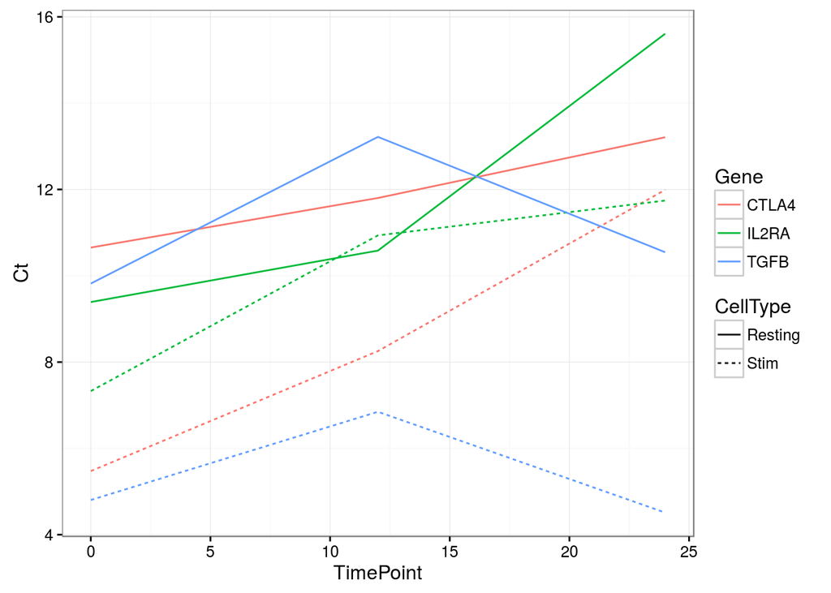

```r
pcr_long %>%
  mutate(TimePoint = str_replace(TimePoint, "hr", ""),
         TimePoint = as.numeric(TimePoint)) %>%
  ggplot(aes(x = TimePoint, y = Ct)) +
  geom_line(aes(colour = Gene, linetype = CellType)) +
  theme_bw()
```

Notice how we changed the `TimePoint` column to a number on the fly, without altering the original object. This is another useful trick.

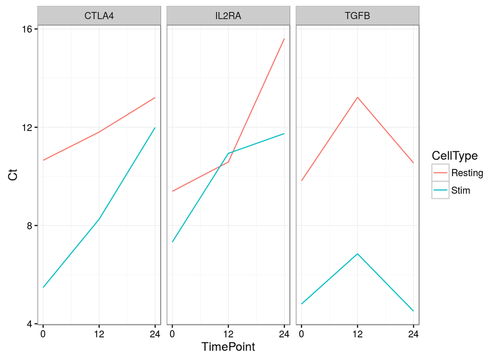

```r
pcr_long %>%
  mutate(TimePoint = str_replace(TimePoint, "hr", ""),
         TimePoint = as.numeric(TimePoint)) %>%
  ggplot(aes(x = TimePoint, y = Ct)) +
  geom_line(aes(colour = CellType)) +
  facet_wrap(~Gene) +
  theme_bw() +
  scale_x_continuous(breaks = c(0, 12, 24))
```